# Machine Learning

Yoji Toriumi

May 2022

# 1 Introduction

This website practices machine learning methods using codes and knowledge that I learned in the course “GOV 2018: Introduction to Machine Learning.”

# 2 K-Nearest Neighbors

In this exercise, I write codes of ‘k-nearest neighbors’ and classify titanic datasets focusing on ‘survived’ variable.

```r
library(titanic)
library(tidyverse)
```

## 2.1 KNN Code

First, clean the datasets for data analysis. Randomly choose 70 % for the train set and 30 % for the test set.

Prepare a function for calculating euclidean distance between two observations.

```r
euclideanDistv <- function(x, y){
  d <- sqrt(sum((x - y)^2))
  return(d)
}
```

Then, write a function named ‘knn’ that calculates euclidean distances between two points in the train set and the test set and returns predicted class labels of test data by counting labels of k neighbors.

```r
knn <- function(test_data, train_data, k_value) {
  pred <- c()  #empty pred vector
  #LOOP-1
  for (i in c(1:nrow(test_data))) {
    eu_dist = c()
    eu_char = c()
    yes = 0
    no = 0

    #LOOP-2-looping over train data
    for (j in c(1:nrow(train_data))) {
      #adding euclidean distance between test data point and train data to eu_dist vector
      eu_dist <-
        c(eu_dist, euclideanDistv(test_data[i, -1], train_data[j, -1])) #remove the Y label (1st column in this case)
      #adding class variable of training data in eu_char
      eu_char <-
        c(eu_char, as.character(train_data[j, 1])) #where Y variable is
    }

    eu <-
      data.frame(eu_char, eu_dist) #eu dataframe created with eu_char & eu_dist columns
    eu <-
      eu[order(eu$eu_dist), ]       #sorting eu dataframe to find top K neighbors
    eu <-
      eu[1:k_value, ]               #eu dataframe with top K neighbors

    #Loop 3: loops over eu and counts classes of neighbors.
    for (k in c(1:nrow(eu))) {
      if (as.character(eu[k, "eu_char"]) == 1) {
        yes = yes + 1
      }
      else
        no = no + 1
    }

    # Compares the no. of neighbors with class label yes or no
    if (yes > no) {
      pred <- c(pred, 1)
    }
    else if (yes < no) {
      pred <- c(pred, 0)
    }

  }
  return(pred) #return pred vector
}
```

## 2.2 KNN Calculation

Create a function called `accuracy` that calculates how accurate the predictions are for the test labels.

```r
accuracy <- function(test_data) {
  correct = 0
  for (i in c(1:nrow(test_data))) {
    if (test_data[i, 1] == test_data$prediction[i]) {
      #If correctly predicted labels
      correct = correct + 1                          #Add +1
    }
  }
  accu = correct / nrow(test_data) * 100  #calculate the ratio
  return(accu)
}
```

Using K=5, predict labels for the testing data using the `knn` function and analyze accuracy of the result.

```r
predictions <- knn(tit_test, tit_train, 5)

tit_test$prediction <- predictions

cat("the accuracy rate for K=5 is:", accuracy(tit_test), "%")
```

```
## the accuracy rate for K=5 is: 82.46269 %
```

# 3 Regression

In this exercise, I predict housing prices in Boston using regression analysis. You can access the data source [here](https://www.kaggle.com/datasets/fedesoriano/the-boston-houseprice-data)

- `MEDV`: Median value of owner-occupied homes in $1000’s
- `RM`: Average number of rooms per dwelling
- `CHAS`: Charles River dummy variable (= 1 if tract bounds river; 0 otherwise)
- `NOX`: Nitric oxides concentration (parts per 10 million)
- `DIS`: Weighted distances to five Boston employment centres
- `PTRATIO`: Pupil-teacher ratio by town

```r
library(foreign)
library(ggplot2)
```

## 3.1 Preparation

First, load the dataset and analyze its summary and plot two variables.

```r
# load data
housing <- read.csv("data/boston.csv")

# examine structure of the data
str(housing)
```

```
## 'data.frame':    506 obs. of  14 variables:
##  $ CRIM   : num  0.00632 0.02731 0.02729 0.03237 0.06905 ...
##  $ ZN     : num  18 0 0 0 0 0 12.5 12.5 12.5 12.5 ...
##  $ INDUS  : num  2.31 7.07 7.07 2.18 2.18 2.18 7.87 7.87 7.87 7.87 ...
##  $ CHAS   : int  0 0 0 0 0 0 0 0 0 0 ...
##  $ NOX    : num  0.538 0.469 0.469 0.458 0.458 0.458 0.524 0.524 0.524 0.524 ...
##  $ RM     : num  6.58 6.42 7.18 7 7.15 ...
##  $ AGE    : num  65.2 78.9 61.1 45.8 54.2 58.7 66.6 96.1 100 85.9 ...
##  $ DIS    : num  4.09 4.97 4.97 6.06 6.06 ...
##  $ RAD    : int  1 2 2 3 3 3 5 5 5 5 ...
##  $ TAX    : num  296 242 242 222 222 222 311 311 311 311 ...
##  $ PTRATIO: num  15.3 17.8 17.8 18.7 18.7 18.7 15.2 15.2 15.2 15.2 ...
##  $ B      : num  397 397 393 395 397 ...
##  $ LSTAT  : num  4.98 9.14 4.03 2.94 5.33 ...
##  $ MEDV   : num  24 21.6 34.7 33.4 36.2 28.7 22.9 27.1 16.5 18.9 ...
```

```r
# first observations
head(housing)
```

```
##      CRIM ZN INDUS CHAS   NOX    RM  AGE    DIS RAD TAX PTRATIO      B LSTAT
## 1 0.00632 18  2.31    0 0.538 6.575 65.2 4.0900   1 296    15.3 396.90  4.98
## 2 0.02731  0  7.07    0 0.469 6.421 78.9 4.9671   2 242    17.8 396.90  9.14
## 3 0.02729  0  7.07    0 0.469 7.185 61.1 4.9671   2 242    17.8 392.83  4.03
## 4 0.03237  0  2.18    0 0.458 6.998 45.8 6.0622   3 222    18.7 394.63  2.94
## 5 0.06905  0  2.18    0 0.458 7.147 54.2 6.0622   3 222    18.7 396.90  5.33
## 6 0.02985  0  2.18    0 0.458 6.430 58.7 6.0622   3 222    18.7 394.12  5.21
##   MEDV
## 1 24.0
## 2 21.6
## 3 34.7
## 4 33.4
## 5 36.2
## 6 28.7
```

```r
# summary statistics of variables
summary(housing)
```

```
##       CRIM                ZN             INDUS            CHAS
##  Min.   : 0.00632   Min.   :  0.00   Min.   : 0.46   Min.   :0.00000
##  1st Qu.: 0.08205   1st Qu.:  0.00   1st Qu.: 5.19   1st Qu.:0.00000
##  Median : 0.25651   Median :  0.00   Median : 9.69   Median :0.00000
##  Mean   : 3.61352   Mean   : 11.36   Mean   :11.14   Mean   :0.06917
##  3rd Qu.: 3.67708   3rd Qu.: 12.50   3rd Qu.:18.10   3rd Qu.:0.00000
##  Max.   :88.97620   Max.   :100.00   Max.   :27.74   Max.   :1.00000
##       NOX               RM             AGE              DIS
##  Min.   :0.3850   Min.   :3.561   Min.   :  2.90   Min.   : 1.130
##  1st Qu.:0.4490   1st Qu.:5.886   1st Qu.: 45.02   1st Qu.: 2.100
##  Median :0.5380   Median :6.208   Median : 77.50   Median : 3.207
##  Mean   :0.5547   Mean   :6.285   Mean   : 68.57   Mean   : 3.795
##  3rd Qu.:0.6240   3rd Qu.:6.623   3rd Qu.: 94.08   3rd Qu.: 5.188
##  Max.   :0.8710   Max.   :8.780   Max.   :100.00   Max.   :12.127
##       RAD              TAX           PTRATIO            B
##  Min.   : 1.000   Min.   :187.0   Min.   :12.60   Min.   :  0.32
##  1st Qu.: 4.000   1st Qu.:279.0   1st Qu.:17.40   1st Qu.:375.38
##  Median : 5.000   Median :330.0   Median :19.05   Median :391.44
##  Mean   : 9.549   Mean   :408.2   Mean   :18.46   Mean   :356.67
##  3rd Qu.:24.000   3rd Qu.:666.0   3rd Qu.:20.20   3rd Qu.:396.23
##  Max.   :24.000   Max.   :711.0   Max.   :22.00   Max.   :396.90
##      LSTAT            MEDV
##  Min.   : 1.73   Min.   : 5.00
##  1st Qu.: 6.95   1st Qu.:17.02
##  Median :11.36   Median :21.20
##  Mean   :12.65   Mean   :22.53
##  3rd Qu.:16.95   3rd Qu.:25.00
##  Max.   :37.97   Max.   :50.00
```

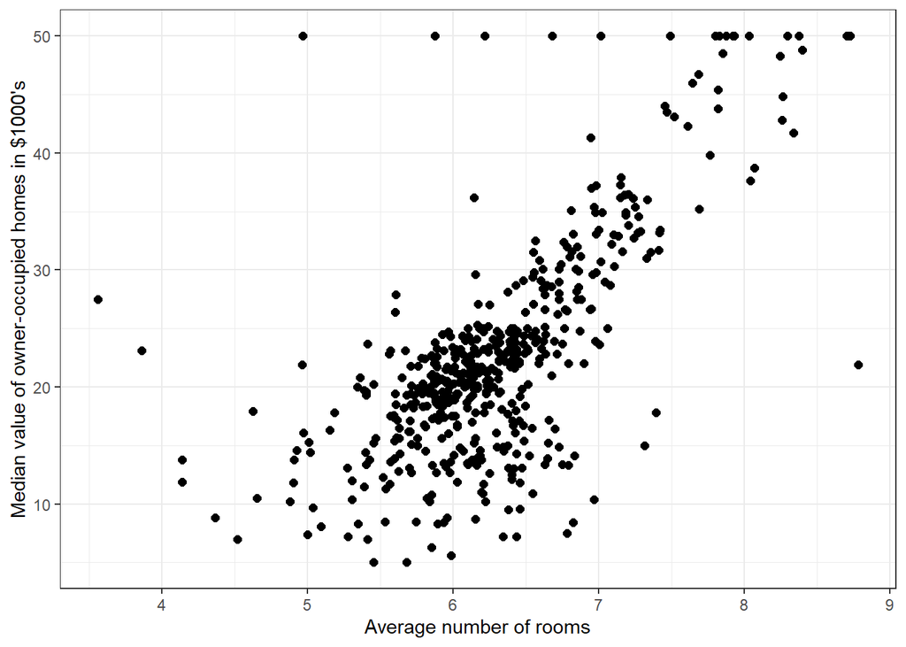

```r
#plot
plot1 <- ggplot(housing, aes(x = RM, y = MEDV)) + geom_point(size = 2) + theme_bw() +
  labs(x= "Average number of rooms",
       y = "Median value of owner-occupied homes in $1000's")
plot1
```

## 3.2 Bivariate regression

Regress the median value of housing prices, against the median number of rooms. Print the results and add the bivariate regression line to the plot.

```r
# the bivariate regression
bivariate <- lm(MEDV ~ RM, data = housing)
summary(bivariate)
```

```
##
## Call:
## lm(formula = MEDV ~ RM, data = housing)
##
## Residuals:
##     Min      1Q  Median      3Q     Max
## -23.346  -2.547   0.090   2.986  39.433
##
## Coefficients:
##             Estimate Std. Error t value Pr(>|t|)
## (Intercept)  -34.671      2.650  -13.08   <2e-16 ***
## RM             9.102      0.419   21.72   <2e-16 ***
## ---
## Signif. codes:  0 '***' 0.001 '**' 0.01 '*' 0.05 '.' 0.1 ' ' 1
##
## Residual standard error: 6.616 on 504 degrees of freedom
## Multiple R-squared:  0.4835, Adjusted R-squared:  0.4825
## F-statistic: 471.8 on 1 and 504 DF,  p-value: < 2.2e-16
```

The summary of the bivariate model reveals that the median room numbers has a positive and statistically significant relationship (9.1) with the median value of housing prices.

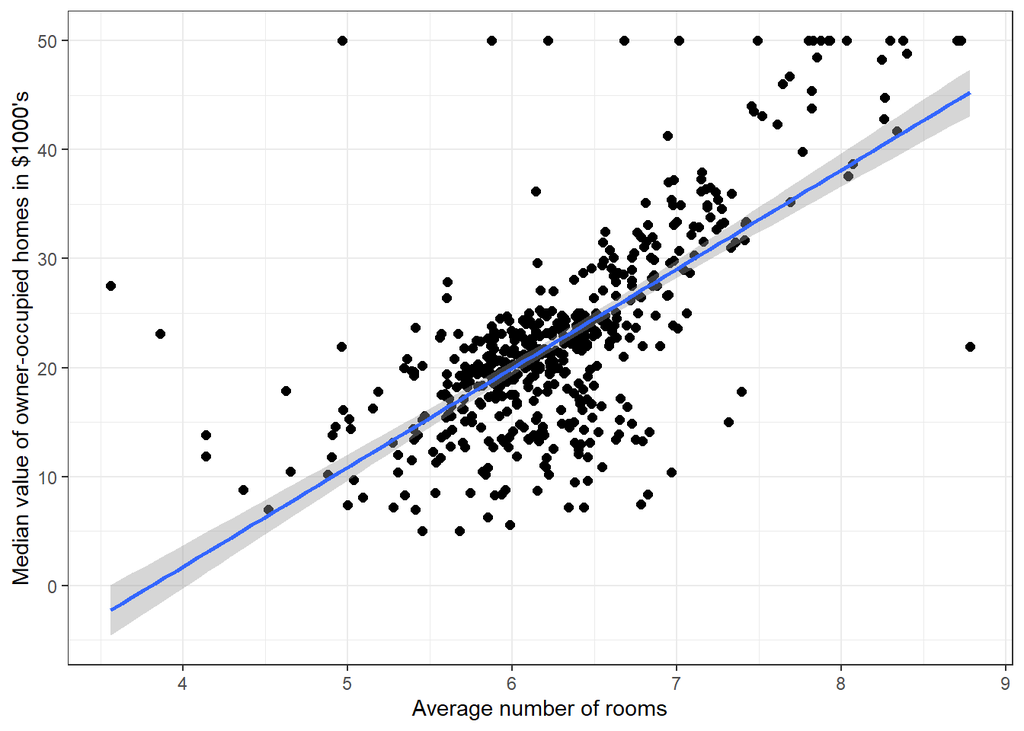

```r
# adding the regression line to plot
plot2 <- plot1 + geom_smooth(method = "lm", se = TRUE)
plot2
```

Using the bivariate regression and a function, calculate the expected median value of housing price if `RM` = 6.28 (mean of the number of rooms).

```r
predict_mine <- function(value, model){
  coef <- model$coefficients
  y <- unname(coef[1] + coef[2]*value)
  return (y)
}

predicted <- predict_mine(6.28, bivariate)
print(predicted)
```

```
## [1] 22.49062
```

The expected value of housing price is 22.49 ($1,000’s).

## 3.3 Multivariate regression

Now, regress `MEDV` on `RM`, `CHAS` `NOX`, `DIS`, and `PTRATIO`.

Using the multivariate regression and a function, calculate the expected median value of housing price if:

- `RM` = 6.28
- `CHAS` = 1
- `NOX` = 0.55
- `DIS` = 3.8
- `PTRATIO` = 18.5

```r
multivariate <- lm(MEDV ~ RM + CHAS + NOX + DIS + PTRATIO, data = housing)
summary(multivariate)
```

```
##
## Call:
## lm(formula = MEDV ~ RM + CHAS + NOX + DIS + PTRATIO, data = housing)
##
## Residuals:
##     Min      1Q  Median      3Q     Max
## -15.386  -3.259  -0.479   2.107  38.705
##
## Coefficients:
##             Estimate Std. Error t value Pr(>|t|)
## (Intercept)  24.0499     5.0261   4.785 2.25e-06 ***
## RM            6.6431     0.3952  16.810  < 2e-16 ***
## CHAS          3.9284     0.9997   3.929 9.71e-05 ***
## NOX         -31.2052     3.4661  -9.003  < 2e-16 ***
## DIS          -0.9312     0.1880  -4.953 1.00e-06 ***
## PTRATIO      -1.2297     0.1261  -9.755  < 2e-16 ***
## ---
## Signif. codes:  0 '***' 0.001 '**' 0.01 '*' 0.05 '.' 0.1 ' ' 1
##
## Residual standard error: 5.595 on 500 degrees of freedom
## Multiple R-squared:  0.6336, Adjusted R-squared:   0.63
## F-statistic: 172.9 on 5 and 500 DF,  p-value: < 2.2e-16
```

After adding other variables to the regression model, I found that all of the five variables are statistically significant with a 99.9%-CI estimator.

Create a prediction function and predict the housing price using the multivariate regression.

```r
multipredict_mine <- function(values, model){
  values <- c(1, values)
  if(length(values) != length(model$coefficients)) stop("!!!") # flag
   y <- values%*%unname(model$coefficients)
   return (y)
}

multi_prediction <- multipredict_mine(c(6.28, 1, 0.55, 3.8, 18.5), multivariate)
print(multi_prediction)
```

```
##          [,1]
## [1,] 26.24587
```

The expected value of housing price is now 26.25 ($1,000’s).

## 3.4 Bootstrap

We are often interested in characterizing the uncertainty in our estimates. One nonparametric approach to estimating uncertainty is the bootstrap. Here, I will walk through the steps to produce a function that will produce a bootstrap distribution, from which we can find the bootstrap estimates (and 95% confidence bands).

```r
n <- 1000 # size of bootstrap

# creating empty vectors for results
bi_results <- rep(NA,n)
multi_results <- rep(NA,n)

for (i in 1:n){
  # create bootstrap data
  sim_data <- housing[sample(nrow(housing), 506, replace = TRUE), ] # number of observations

  # run bivariate and multivariate regressions using this data
  bi <- lm(MEDV ~ RM, data = sim_data)
  multi <- lm(MEDV ~ RM + CHAS + NOX + DIS + PTRATIO, data = sim_data)

  # use the functions to make predictions and store
  bi_results[i] <- predict_mine(6.28, bi)
  multi_results[i] <- multipredict_mine(c(6.28, 1, 0.55, 3.8, 18.5), multi)
}

# putting predictions in data frame for the next question
predicted_vals <- as.data.frame(cbind(bi_results, multi_results))
```

Create histograms for both predictions adding lines for the prediction and 95% confidence bands.

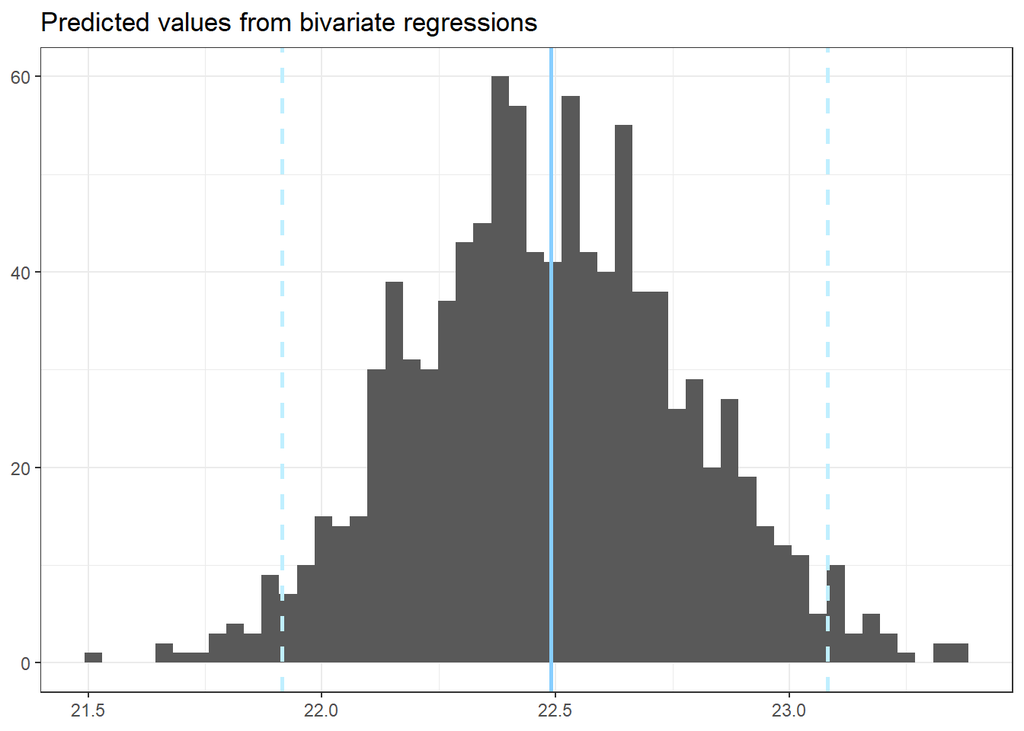

```r
biplot <- ggplot(predicted_vals, aes(bi_results)) +
  geom_histogram(bins=50) +
  theme_bw() +
  labs(x= NULL, y = NULL,
       title = "Predicted values from bivariate regressions")

biplot +
  # prediction from Q3
  geom_vline(xintercept = predicted, linetype="solid", color = "skyblue1", size=1) +
  # lower bound of confidence interval
  geom_vline(xintercept = sort(predicted_vals$bi_results)[round(0.025*nrow(predicted_vals),0)],
             linetype="dashed", color = "lightblue1", size=1) +
  # upper bound of confidence interval
  geom_vline(xintercept = sort(predicted_vals$bi_results)[round(0.975*nrow(predicted_vals),0)],
             linetype="dashed", color = "lightblue1", size=1)
```

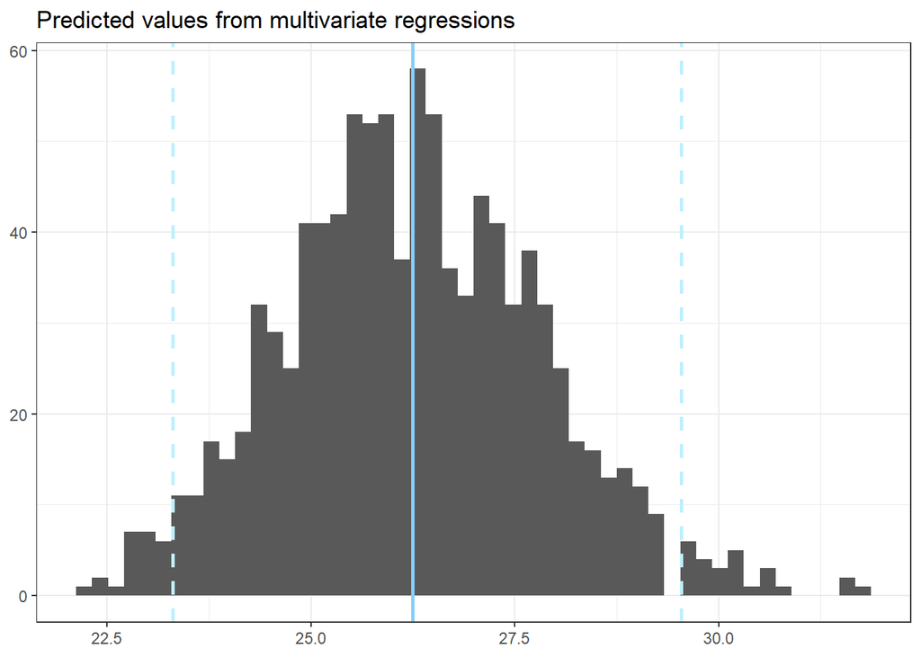

```r
multiplot <- ggplot(predicted_vals, aes(multi_results)) +
  geom_histogram(bins=50) +
  theme_bw() +
  labs(x= NULL, y = NULL,
       title = "Predicted values from multivariate regressions")

multiplot +
  # prediction from Q4
  geom_vline(xintercept = multi_prediction, linetype="solid", color = "skyblue1", size=1) +
  # lower bound of confidence interval
  geom_vline(xintercept = sort(predicted_vals$multi_results)[round(0.025*nrow(predicted_vals),0)],
             linetype="dashed", color = "lightblue1", size=1) +
  # upper bound of confidence interval
  geom_vline(xintercept = sort(predicted_vals$multi_results)[round(0.975*nrow(predicted_vals),0)],
             linetype="dashed", color = "lightblue1", size=1)
```

# 4 Lasso

In this exercise, I classify numbers of ‘6’ and ‘8’ by using LASSO regression and analyze accuracy of several models.

I use `dslabs` package to extract the dataset.

```r
library(glmnet)
library(tidyverse)
library(dslabs)
```

## 4.1 Preparation

First, load the dataset from the dslabs package. The dataset is composed of labels from 0 to 9 and 28 by 28 matrix.

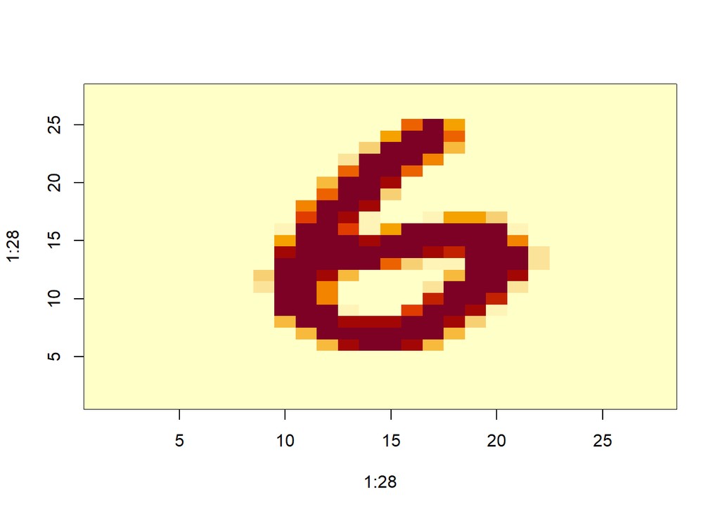

```r
mnist <- read_mnist()

# set seed for this exercise
set.seed(2022)

ind <- which(mnist$train$labels %in% c(6,8)) %>% sample(1000) # extract 1000 samples of '6' and '8'
data <- mnist$train$images[ind,]
data_label <- mnist$train$labels[ind]
data_label <- ifelse(data_label == 6, 0, 1)

smp_size <- floor(0.7 * 1000)
train_ind <- sample(seq_len(1000), size = smp_size)

train <- data[train_ind, ]
train_label <- data_label[train_ind]

test <- data[-train_ind, ]
test_label <- data_label[-train_ind]

# visualize the first 8 and 6
image(1:28, 1:28, matrix(train[1,], 28, 28)[, 28:1])
```

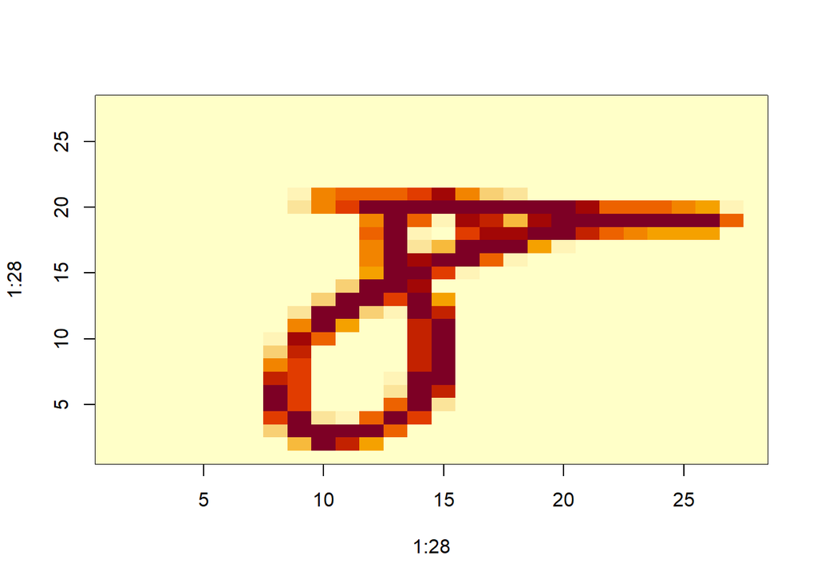

```r
image(1:28, 1:28, matrix(train[2,], 28, 28)[, 28:1])
```

## 4.2 Regression

Using the `lm` function, regress `train_label` against all train datasets.

```r
full_reg <- lm(train_label ~ ., data = as.data.frame(train))
len <- length(which(is.na(full_reg$coeff)==T))
```

There are 265 `na` coefficients

Now make predictions using the training data and the test data and compare their properties.

Using the `predict` function, make predictions for all observations in the training set. Then, classify the numbers as 6 or 8 using a threshold of 0.5. Create a 2x2 table of the predicted train labels and true train label.

```r
train_pred <- predict(full_reg, as.data.frame(train))

train_class_pred <- ifelse(train_pred > 0.5, 1, 0)

table(train_class_pred, train_label)
```

```
##                 train_label
## train_class_pred   0   1
##                0 329   0
##                1   0 371
```

Assess the accuracy of the classification by comparing it to the actual test data.

```r
# predict test observations
test_pred <- predict(full_reg, as.data.frame(test))

# classify using threshold of 0.5
test_class_pred <- ifelse(test_pred > 0.5, 1, 0)

# create confusion matrix
table(test_class_pred, test_label)
```

```
##                test_label
## test_class_pred   0   1
##               0 135  15
##               1  13 137
```

```r
# Get accuracy score of my predictions
acc1 <-(sum(test_class_pred & test_label) + sum(!test_class_pred & !test_label)) / length(test_label)
acc1
```

```
## [1] 0.9066667
```

```r
rand_guess <- rbinom(length(test_label),
                     prob = sum(train_label)/length(train_label), # the proportion of 8s in the train labels
                     size = 1)
acc2 <- sum(diag(table(rand_guess, test_label)))/length(test_label)
acc2
```

```
## [1] 0.4933333
```

## 4.3 Fit LASSO Regression

Try to improve the result of the test datasets by using LASSO regression that is available in the `glmnet` library.

```r
library(glmnet)
lasso <- glmnet(x = as.data.frame(train), y = train_label)
```

The LASSO function automatically fits the model for several values of $\lambda$, and produces $\beta$ values for all covariates for each value of $\lambda$ all of which is found in the object `lasso$beta`.

Sum up the absolute values of `lasso$beta` for each column. Plot that against `lasso$lambda`.

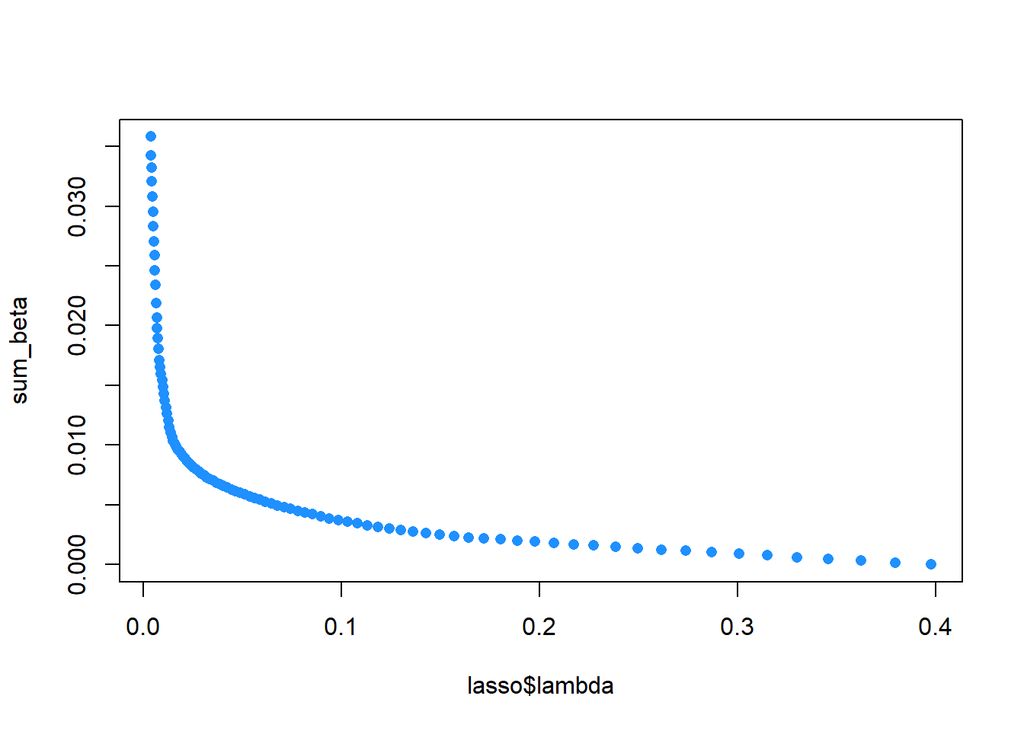

```r
# sum absolute values of the betas
sum_beta <- colSums(abs(lasso$beta))

# plot against values of lambda
plot(sum_beta ~ lasso$lambda, pch=16, col="dodgerblue1")
```

As $\lambda$ increases, the number of $\beta$ coefficients (and hence the sum) gets pushed down to 0, increasing regularization.

In this case, I set a particular value of lambda arbitrarily and then assess its performance. I will set lambda to 0.02.

Formulate predictions for the training set using the following syntax: `lasso_pred <- predict(lasso, newx=train, s = 0.05 )`

- `lasso` is the lasso regression
- `newx` are the values you want to predict
- `s` is the value of lambda.

Classify the observations using a threshold of 0.5. Then assess the accuracy of those predictions by comparing them to the training set labels and create a confusion matrix.

```r
# formulate predictions
lasso_pred <- predict(lasso, newx = train, s = 0.02)

# classify obs using threshold of 0.5
class_lasso1 <- ifelse(lasso_pred > 0.5, 1, 0)

# create confusion matrix
table(class_lasso1, train_label)
```

```
##             train_label
## class_lasso1   0   1
##            0 327   5
##            1   2 366
```

```r
# get accuracy score
(sum(class_lasso1 & train_label) + sum(!class_lasso1 & !train_label)) / length(train_label)
```

```
## [1] 0.99
```

```r
# classify obs using threshold with prior
class_lasso2 <- ifelse(lasso_pred > sum(train_label)/length(train_label), 1, 0)

# create confusion matrix
table(class_lasso2, train_label)
```

```
##             train_label
## class_lasso2   0   1
##            0 327   7
##            1   2 364
```

```r
# get accuracy score
(sum(class_lasso2 & train_label) + sum(!class_lasso2 & !train_label)) / length(train_label)
```

```
## [1] 0.9871429
```

Notice that I don’t have the perfect in-sample fit that I had before. It means that I am not overfitting the data.

Now formulate predictions for the test set. Classify the numbers as 6 or 8 with a threshold using the prior proportion of 1 labels in the training set as well as 0.5, and assess the accuracy of those predictions by comparing them to the test set labels.

```r
# formulate predictions
lasso_test <- predict(lasso, newx = test, s = 0.02)

# classify obs using threshold of prior info
class_lasso_test <- ifelse(lasso_test > sum(train_label)/length(train_label), 1, 0)

# create confusion matrix
table(class_lasso_test, test_label)
```

```
##                 test_label
## class_lasso_test   0   1
##                0 145   6
##                1   3 146
```

```r
# get accuracy score
acc3 <- (sum(class_lasso_test & test_label) + sum(!class_lasso_test & !test_label)) / length(test_label)
acc3
```

```
## [1] 0.97
```

```r
# classify obs using threshold of 0.5
class_lasso_test2 <- ifelse(lasso_test > 0.5, 1, 0)

# create confusion matrix
table(class_lasso_test2, test_label)
```

```
##                  test_label
## class_lasso_test2   0   1
##                 0 144   6
##                 1   4 146
```

```r
# get accuracy score
acc4<-(sum(class_lasso_test2 & test_label) + sum(!class_lasso_test2 & !test_label)) / length(test_label)
acc4
```

```
## [1] 0.9666667
```

As a result of LASSO, the accuracy of the test sets are improved.

Lastly, compare accuracies by setting different lambdas.

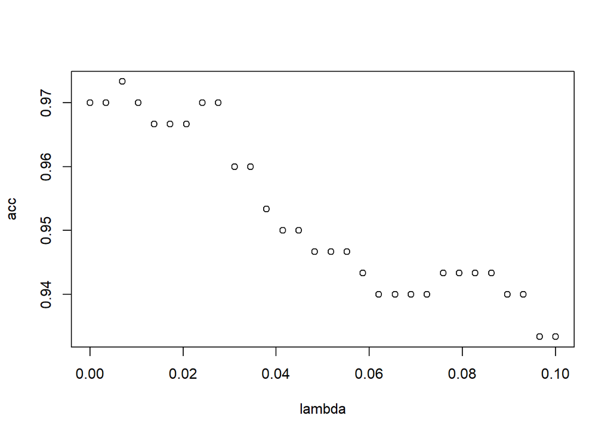

```r
lambda <- seq(0, 0.1, len = 30)
acc <- rep(NA, 30)
for (i in c(1:30)) {
    lasso_test <- predict(lasso, newx = test, s = lambda[i])
    class_lasso_test <-
      ifelse(lasso_test > sum(test_label) / length(test_label),
             1,
             0)
    lasso_acc <-
      (
        sum(class_lasso_test &
              test_label) + sum(!class_lasso_test &
                                       !test_label)
      ) / length(test_label)
    acc[i] <- lasso_acc
  }
plot(lambda, acc)
```

# 5 Cross Validation

In this exercise, I predict housing price in California using the dataset [here](https://www.kaggle.com/datasets/fedesoriano/california-housing-prices-data-extra-features). I use ridge and lasso models for this analysis and figure out the best model using cross validation.

```r
library(ISLR)
library(glmnet)
library(dplyr)
library(tidyr)
library(tidyverse)
```

## 5.1 Preparation

First, load the dataset and divide it to predictors and response variable.

```r
california <- read_csv("data/California_Houses.csv") %>% select(-8, -9)

# set seed for this exercise
set.seed(2022)

data <- model.matrix(Median_House_Value ~ .,  california)[, -1] %>% scale() # predictors
label <- california$Median_House_Value # response variable
```

## 5.2 Ridge Regression

The `glmnet()` function has an alpha argument that determines what type of model is fit. If `alpha = 0` then a ridge regression model is fit, and if `alpha = 1` then a lasso model is fit.

```r
grid = 10^seq(10, -2, length = 100)
ridge_mod = glmnet(data, label, alpha = 0, lambda = grid) # alpha = 0 means `ridge`
```

By default the `glmnet()` function performs ridge regression for an automatically selected range of $\lambda$ values. However, here I have chosen to implement the function over a grid of values ranging from $\lambda = 10^{10}$ to $\lambda = 10^{-2}$, essentially covering the full range of scenarios from the null model containing only the intercept, to the least squares fit.

Associated with each value of $\lambda$ is a vector of ridge regression coefficients, stored in a matrix that can be accessed by `coef()`. In this case, it is a $12 \times 100$ matrix, with 12 rows (one for each predictor, plus an intercept) and 100 columns (one for each value of $\lambda$).

```r
dim(coef(ridge_mod))
```

```
## [1]  12 100
```

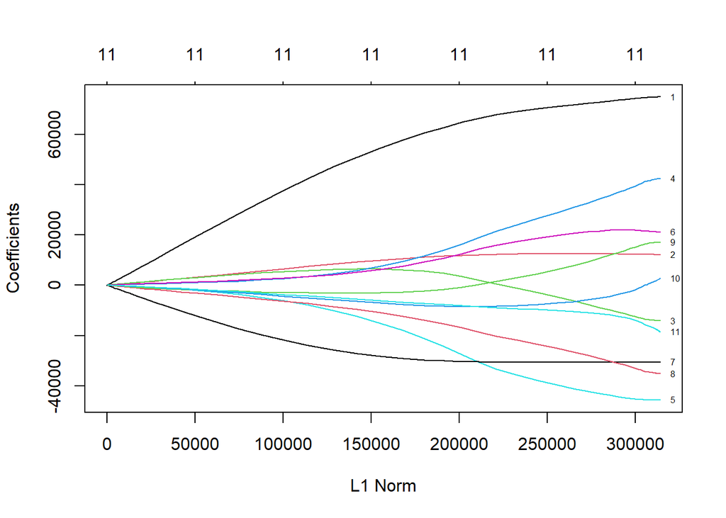

```r
plot(ridge_mod, label = TRUE)
```

I expect the coefficient estimates to be much smaller, in terms of $l_2$ norm, when a large value of $\lambda$ is used, as compared to when a small value of $\lambda$ is used.

```r
ridge_mod$lambda[50] # Display 50th lambda value
```

```
## [1] 11497.57
```

```r
coef(ridge_mod)[,50] # Display coefficients associated with 50th lambda value
```

```
##              (Intercept)            Median_Income               Median_Age
##               206855.817                64738.295                11935.685
##                Tot_Rooms             Tot_Bedrooms               Population
##                 3532.137                16439.170               -27564.945
##               Households        Distance_to_coast           Distance_to_LA
##                12595.292               -30319.669               -16933.116
##     Distance_to_SanDiego      Distance_to_SanJose Distance_to_SanFrancisco
##                 -844.649                -8500.636                -8155.774
```

```r
sqrt(sum(coef(ridge_mod)[-1,50]^2)) # Calculate l2 norm
```

```
## [1] 82946.98
```

How about coefficients when $\lambda$ is at its 60th value and their $l_2$ norm?

```r
ridge_mod$lambda[60] #Display 60th lambda value
```

```
## [1] 705.4802
```

```r
coef(ridge_mod)[,60] # Display coefficients associated with 60th lambda value
```

```
##              (Intercept)            Median_Income               Median_Age
##               206855.817                73587.403                12408.935
##                Tot_Rooms             Tot_Bedrooms               Population
##               -10692.971                36915.401               -44273.875
##               Households        Distance_to_coast           Distance_to_LA
##                21944.196               -30649.311               -30993.637
##     Distance_to_SanDiego      Distance_to_SanJose Distance_to_SanFrancisco
##                13011.975                -3654.478               -12295.652
```

```r
sqrt(sum(coef(ridge_mod)[-1,60]^2)) # Calculate l2 norm
```

```
## [1] 108267
```

Split the samples into a 80% training set and a 20% test set in order to estimate the test error of ridge regression and the lasso.

```r
set.seed(2022)
index<-sample(nrow(california),replace=TRUE) # to permute the row index
california<-california[index,]
label<-label[index]

train = california[1:round(nrow(california)*0.8,0),]
test = california[(round(nrow(california)*0.8,0)+1):nrow(california),]

data_train = model.matrix(Median_House_Value ~ ., train)[,-1] %>% scale()
data_test = model.matrix(Median_House_Value ~ ., test)[,-1] %>% scale()
label_train = train$Median_House_Value
label_test = test$Median_House_Value
```

Next I fit a ridge regression model on the training set, and evaluate its MSE on the test set, using $\lambda = 40$.

```r
set.seed(2022)
ridge_mod = glmnet(data_train, label_train, alpha=0, lambda = grid, thresh = 1e-12)
ridge_pred = predict(ridge_mod, s = 40, newx = data_test)
mse1<-mean((ridge_pred - label_test)^2)
mse1
```

```
## [1] 4912568797
```

The test MSE is 4.9125688^{9}.

```r
set.seed(2022)
cv.out = cv.glmnet(data_train, label_train, alpha = 0, nfolds=20) # Fit ridge regression model on training data
bestlam = cv.out$lambda.min  # Select lamda that minimizes training MSE
bestlam
```

```
## [1] 8049.134
```

Therefore, I see that the value of $\lambda$ that results in the smallest cross-validation error is 8049.1342962.

Plot the MSE as a function of $\lambda$ by using `plot()` on the returned object.

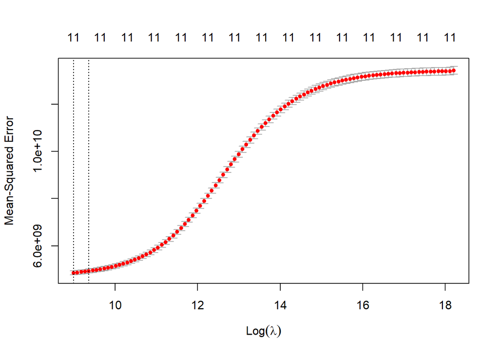

```r
plot(cv.out)
```

Then, calculate the test MSE associated with this value of $\lambda$.

```r
ridge_pred = predict(ridge_mod, s = bestlam, newx = data_test) # Use best lambda to predict test data
mse2<-mean((ridge_pred - label_test)^2) # Calculate test MSE
mse2
```

```
## [1] 5098689041
```

Refit the ridge regression model on the full data set, using the value of $\lambda$ chosen by cross-validation.

```r
out = glmnet(data, label, alpha = 0) # Fit ridge regression model on full dataset
predict(out, type = "coefficients", s = bestlam)[1:12,] # Display coefficients using lambda chosen by CV
```

```
##              (Intercept)            Median_Income               Median_Age
##             207789.14201               -338.21654                -26.74189
##                Tot_Rooms             Tot_Bedrooms               Population
##              -1143.61837                767.17884              -1287.35592
##               Households        Distance_to_coast           Distance_to_LA
##               2261.51275               -532.80954               1190.27507
##     Distance_to_SanDiego      Distance_to_SanJose Distance_to_SanFrancisco
##              -1767.00505               -798.28964               -979.74199
```

As expected, none of the coefficients are exactly zero - ridge regression does not perform variable selection.

## 5.3 The Lasso

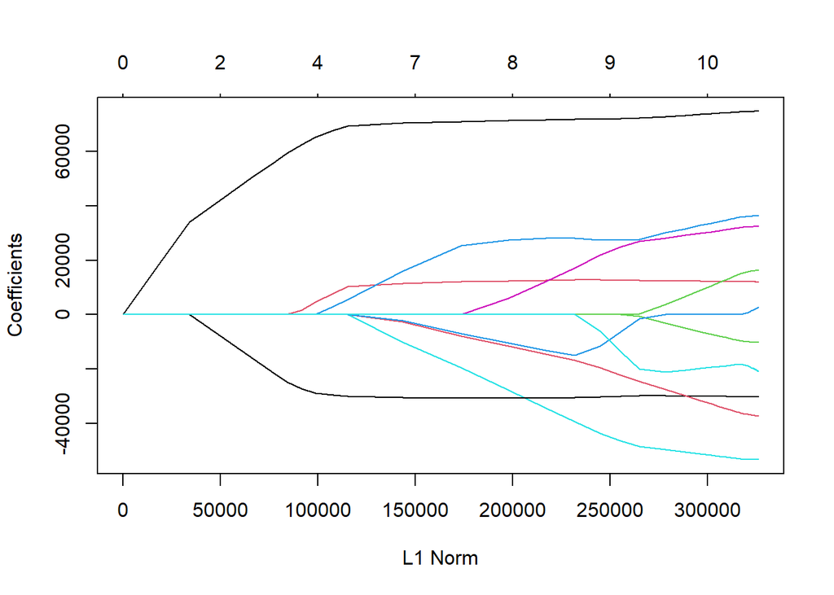

```r
set.seed(2022)
lasso_mod = glmnet(data_train,
                   label_train,
                   alpha = 1, # alpha = 1 means `lasso`
                   lambda = grid) # Fit lasso model on training data

plot(lasso_mod)    # Draw plot of coefficients
```

Notice that in the coefficient plot that depending on the choice of tuning parameter, some of the coefficients are exactly equal to zero.

Now perform cross-validation with folds equal to 10 and compute the associated test error:

```r
set.seed(2022)
cv.out = cv.glmnet(data_train, label_train, alpha = 1, nfolds = 10) # Fit lasso model on training data
bestlam = cv.out$lambda.min
bestlam
```

```
## [1] 90.41786
```

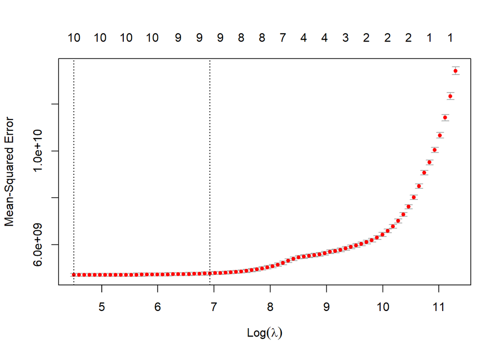

```r
plot(cv.out) # Draw plot of training MSE as a function of lambda
```

```r
bestlam = cv.out$lambda.min # Select lamda that minimizes training MSE
lasso_pred = predict(lasso_mod, s = bestlam, newx = data_test) # Use best lambda to predict test data
mse3<-mean((lasso_pred - label_test)^2) # Calculate test MSE
mse3
```

```
## [1] 4917014382
```

## 5.4 K-fold cross validation

Conduct K-fold cross validation for the ridge and lasso, with $k\in\{5,7,9,11,13,15\}$. Assess the models at each $k$ value by calculating the risk/prediction error in the test set and suggest the best $k$ for each.

```r
set.seed(2022)
K<-seq(5,15,2)
mse<-data.frame(ridge=rep(NA,length(K)),lasso=rep(NA,length(K)))
for(k in 1:length(K)){
  cv.lasso = cv.glmnet(data_train, label_train, alpha = 1, nfolds = K[k], lambda = grid)
  cv.ridge = cv.glmnet(data_train, label_train, alpha = 0, nfolds = K[k], lambda = grid)
  lasso_pred = predict(lasso_mod, s = cv.lasso$lambda.min, newx = data_test)
  ridge_pred = predict(ridge_mod, s = cv.ridge$lambda.min, newx = data_test) # Use best lambda to predict test data
  mse$ridge[k]<-mean((ridge_pred - label_test)^2) # Calculate test MSE
  mse$lasso[k]<-mean((lasso_pred - label_test)^2)
  cat("For k=",K[k],", MSE for ridge is = ", mse$ridge[k],"\n")
  cat("For k=",K[k],", MSE for lasso is = ", mse$lasso[k],"\n")
}
```

```
## For k= 5 , MSE for ridge is =  4913532185
## For k= 5 , MSE for lasso is =  4914116531
## For k= 7 , MSE for ridge is =  4911936127
## For k= 7 , MSE for lasso is =  4914772142
## For k= 9 , MSE for ridge is =  4913532185
## For k= 9 , MSE for lasso is =  4913197649
## For k= 11 , MSE for ridge is =  4911936127
## For k= 11 , MSE for lasso is =  4913278455
## For k= 13 , MSE for ridge is =  4913532185
## For k= 13 , MSE for lasso is =  4912643700
## For k= 15 , MSE for ridge is =  4913139566
## For k= 15 , MSE for lasso is =  4912583512
```

```r
cat("Best ridge k is: ",K[which(mse$ridge==min(mse$ridge))],"\n")
```

```
## Best ridge k is:  7 11
```

```r
cat("Best lasso k is: ",K[which(mse$lasso==min(mse$lasso))],"\n")
```

```
## Best lasso k is:  15
```

```r
min(mse)
```

```
## [1] 4911936127
```

Best final model: ridge with k=7.

# 6 Ramdom Forest

In this exercise, I compare random forest with logistic regression for predicting edible and poisonous mushrooms.

```r
library(randomForest) #for random forests
library(caret) # for CV folds and data splitting
library(ROCR) # for diagnostics and ROC plots/stats
library(pROC) # same as ROCR
library(xtable) # for writing Table 1 in Latex
library(tidyverse)
library(party) # for visualizing trees
```

## 6.1 Preparation

I use mushroom datasets that you can access [here](https://www.kaggle.com/datasets/uciml/mushroom-classification) and classify edible and poisonous mushrooms. The datasets contain 23 variables and I just focus on the first five variables including mushroom classes.

- `classes`: edible=e, poisonous=p
- `cap-shape`: bell=b,conical=c,convex=x,flat=f, knobbed=k,sunken=s
- `cap-surface`: fibrous=f,grooves=g,scaly=y,smooth=s
- `cap-color`: brown=n,buff=b,cinnamon=c,gray=g,green=r,pink=p,purple=u,red=e,white=w,yellow=y
- `bruises`: bruises=t,no=f

```r
#Read data
data<-read.csv("data/mushrooms.csv")[, c(1:5)]
col_names <- names(data)
data[,col_names] <- lapply(data[,col_names] , factor)

table(data$class)
```

```
##
##    e    p
## 4208 3916
```

I use the cross-validation function from the `caret` package. Divide the 70% of the datasets for training and 30 % for testing.

```r
tc<-caret::trainControl(method="cv", # the resampling method
                        number=10, # the number of folds
                        summaryFunction=twoClassSummary, # a function to compute performance metrics across resamples.
                                                         # twoClassSummary computes sensitivity, specificity and the AUC
                        classProb=T, # class probabilities be computed for classification models
                                     # (along with predicted values) in each resample
                        savePredictions = T)

# Set train and test data
set.seed(2022)
smp_size <- floor(0.7 * nrow(data))
train_ind <- sample(nrow(data), size = smp_size)
mush_train <- data[train_ind, ]
mush_test <- data[-train_ind, ]
```

## 6.2 Regression

Run the `train` function in the `caret` library with metric as `ROC`, method as `glm`, family as `binomial`, trControl as my set `tc`, and my training data, on the above specification.

```r
model_glm<- caret::train(class ~ .,
                          metric="ROC", method="glm", family="binomial", trControl=tc, data=mush_train)
summary(model_glm)
```

```
##
## Call:
## NULL
##
## Deviance Residuals:
##     Min       1Q   Median       3Q      Max
## -1.9678  -0.7188  -0.2450   0.7158   2.7972
##
## Coefficients:
##               Estimate Std. Error z value Pr(>|z|)
## (Intercept)    0.99717    0.31496   3.166 0.001545 **
## cap.shapec    17.21571  581.30277   0.030 0.976374
## cap.shapef     2.04503    0.19608  10.430  < 2e-16 ***
## cap.shapek     1.94208    0.21755   8.927  < 2e-16 ***
## cap.shapes   -13.47911  316.88710  -0.043 0.966071
## cap.shapex     1.82218    0.19355   9.415  < 2e-16 ***
## cap.surfaceg  17.69429  858.46801   0.021 0.983556
## cap.surfaces   1.23418    0.09474  13.027  < 2e-16 ***
## cap.surfacey   1.67030    0.09757  17.119  < 2e-16 ***
## cap.colorc    -4.96227    0.53993  -9.191  < 2e-16 ***
## cap.colore    -2.55016    0.25889  -9.850  < 2e-16 ***
## cap.colorg    -3.00202    0.25837 -11.619  < 2e-16 ***
## cap.colorn    -3.37859    0.25455 -13.273  < 2e-16 ***
## cap.colorp    -1.29555    0.34165  -3.792 0.000149 ***
## cap.colorr   -20.19254  459.60590  -0.044 0.964957
## cap.coloru   -20.17784  375.24469  -0.054 0.957116
## cap.colorw    -3.19114    0.26033 -12.258  < 2e-16 ***
## cap.colory    -1.91769    0.26318  -7.287 3.18e-13 ***
## bruisest      -2.93210    0.08596 -34.111  < 2e-16 ***
## ---
## Signif. codes:  0 '***' 0.001 '**' 0.01 '*' 0.05 '.' 0.1 ' ' 1
##
## (Dispersion parameter for binomial family taken to be 1)
##
##     Null deviance: 7874.7  on 5685  degrees of freedom
## Residual deviance: 5340.3  on 5667  degrees of freedom
## AIC: 5378.3
##
## Number of Fisher Scoring iterations: 14
```

```r
model_glm
```

```
## Generalized Linear Model
##
## 5686 samples
##    4 predictor
##    2 classes: 'e', 'p'
##
## No pre-processing
## Resampling: Cross-Validated (10 fold)
## Summary of sample sizes: 5117, 5117, 5117, 5118, 5118, 5118, ...
## Resampling results:
##
##   ROC        Sens       Spec
##   0.8634828  0.8056267  0.799504
```

## 6.3 Random Forest

Next, I run random forest with method as `rf`.

```r
model_rf<-caret::train(class ~ .,
                       metric="ROC", method="rf",
                       sampsize=c(50,50),
                       importance=T, #Variable importance measures retained
                       proximity=F, #https://stats.stackexchange.com/questions/137358/what-is-meant-by-proximity-in-random-forests
                       ntree=1000, trControl=tc, data=mush_train)
```

Visualize importance of variables.

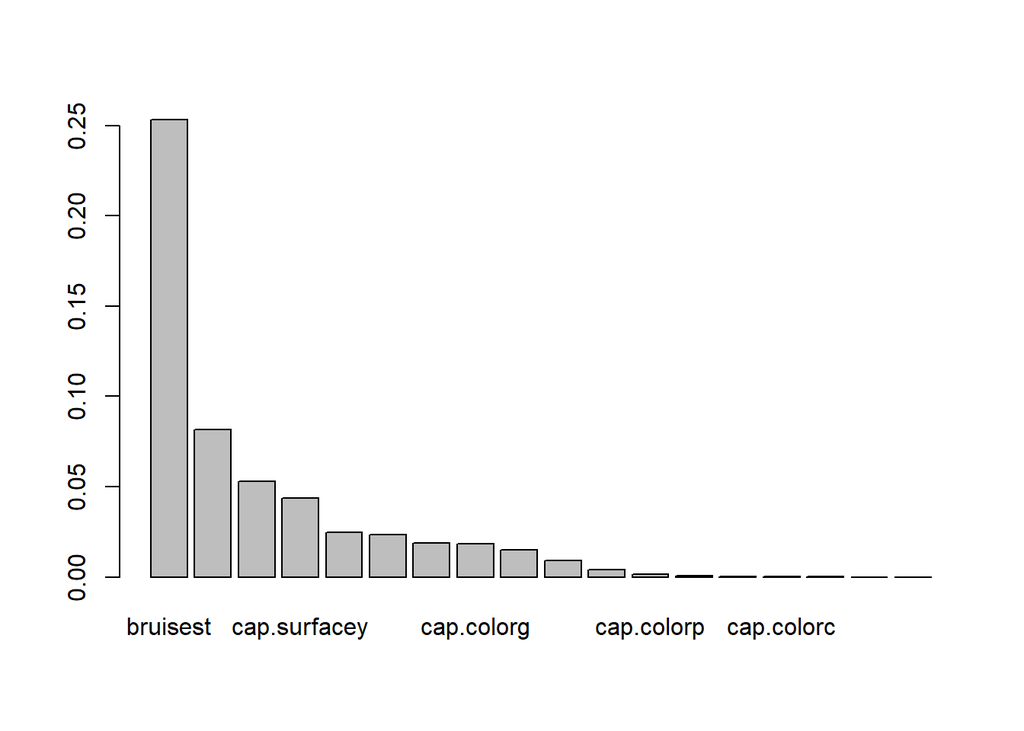

```r
model_rf_imp <-
  sort(importance(model_rf$finalModel, type = 1, scale = FALSE)[, 1],
       decreasing = TRUE)
barplot(model_rf_imp, names.arg = rownames(model_rf_imp))
```

`bruises` contributes the most to the model.

## 6.4 ROC Curve

I now create ROC plots for different models:

- Collect the predicted probabilities for the outcome from each of the above models
- Calculate the performance of the classifier in terms of true positive and false positive rates.
- Plot the ROC curves of the classic logistic regression and the RF model.

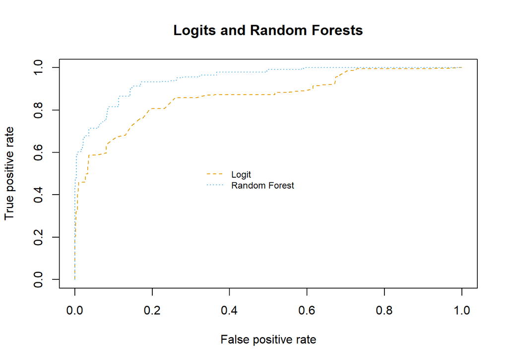

```r
library(ROCR)

cbp1 <- c("#E69F00", "#56B4E9",
          "#0072B2", "#D55E00")

# with the highest AUC score in the caret CV procedure.
pred_model_glm <- model_glm$finalModel$fitted.values # extracts the predicted probabilities
pred_model_rf <- predict(model_rf$finalModel, type="prob") %>% as.data.frame()

# Plot ROC Curves
pred_glm <- prediction(pred_model_glm, mush_train$class)
perf_glm <- performance(pred_glm, "tpr","fpr")

pred_rf <-prediction(pred_model_rf$p, mush_train$class)
perf_rf <-performance(pred_rf, "tpr", "fpr")

plot(perf_glm, main="Logits and Random Forests", lty = 2, col=cbp1[1])
plot(perf_rf, add=T, lty=3, col=cbp1[2])
legend(0.32, 0.55, c("Logit", "Random Forest" ), lty=c(2,3), bty="n", cex = .75, col=cbp1[1:2])
```

Notice that the random forest performs better than the logistical regression

## 6.5 Evaluate Prediction

Finally, evaluate out of sample prediction of the logistical regression and the RF model.

Pull out the testing data and evaluate each of the model predictions on the testing data by focusing on true positives.

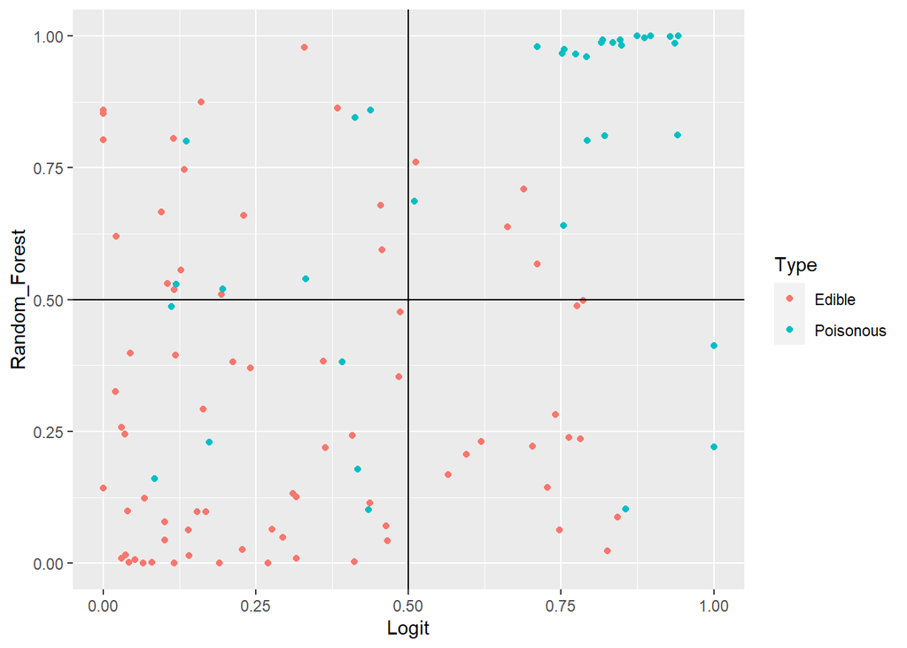

```r
glm_pred <- predict(model_glm, newdata=mush_test, type="prob") %>% as.data.frame()
rf_pred <- predict(model_rf, newdata=mush_test, type="prob") %>% as.data.frame()
predictions <- cbind(mush_test$class, glm_pred[,2], rf_pred[,2])

colnames(predictions) <- c("Type", "Logit", "Random_Forest")
predictions <- as.data.frame(predictions)
predictions$Type <- as.factor(predictions$Type)
predictions$Type <- ifelse(predictions$Type == "1", "Edible", "Poisonous")

ggplot(predictions) +
  geom_point(aes(x = Logit, y = Random_Forest, color = Type)) +
  geom_vline(xintercept = 0.5) +
  geom_hline(yintercept = 0.5)
```

# 7 Neural Networks

The aim of the exercise is to classify binary categorical data born by `CrecentMoon` function using a neural network I write from scratch.

```r
library(RSSL)
library(tidyverse)
```

## 7.1 Prepare Datasets

First, generate the dataset and plot the data `d` to take a look at what the data actually looks like. `d` is composed of two parts, the `x` data, which consists of two features, and the `class` output vector, a factor that takes 0 and 1 as values.

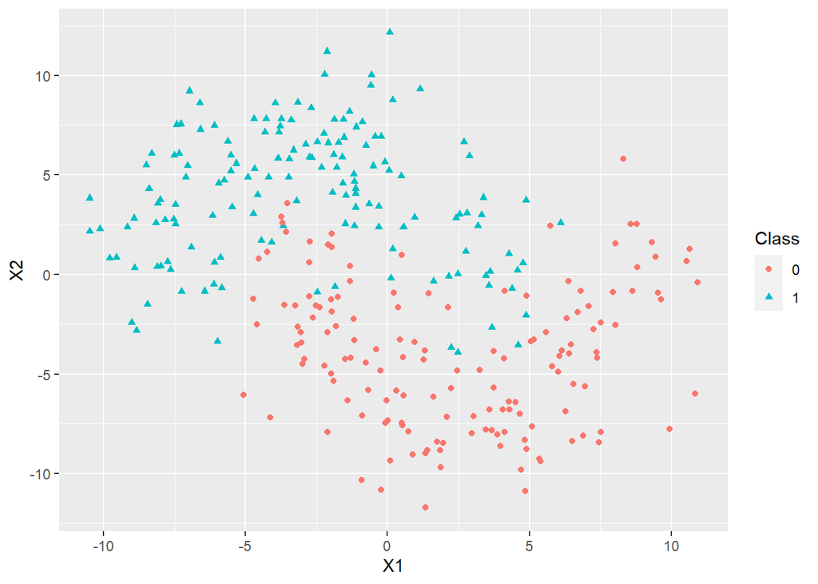

```r
set.seed(2022)
d <- generateCrescentMoon(150, 2, 2)
d$Class = ifelse(d$Class == "+", "1","0")

ggplot(d, aes(x=X1, y=X2, color=Class, shape=Class)) +  geom_point()
```

```r
x <- data.matrix(d[, 2:3])
y <- d$Class == "1" # logical version
dy <- as.factor(ifelse(d$Class == "1", 1, 0))  # factor version
```

## 7.2 Forward Propagation

Write a forward propagation function (I use the sigmoid function for the activation). The function takes `x`, `w1` and `w2` as arguments and output the sigmoid of z2 and `h` (sigmoid of z1).

```r
sigmoid <- function(x) 1 / (1 + exp(-x)) # prepare sigmoid function

# Forward propagation function
feedforward <- function(x, w1, w2) {
  # Compute linear combination of features using weight matrix (W_in)
  z1 <- cbind(1, x) %*% w1
  # Apply activation fn to get nodes in hidden layer
  h <- sigmoid(z1)
  # For output layer, compute linear combination of hidden variables, this time using another weight matrix (W_out)
  z2 <- cbind(1, h) %*% w2
  # Apply one more function to get the output
  output <- sigmoid(z2)
  return(list(output = output,
              h = h))
}
```

## 7.3 Back Propagation

Write a back propagation function. The function takes as arguments: `x`, `y`, `yhat`, `w1`, `w2`, `h`, and the learning rate. It should return a list with `w1` and `w2`.

```r
# Back propagation function
backpropagate <- function(x, y, y_hat, w1, w2, h, learn_rate) {
  # Gradient of the log-likelihood w.r.t the output weights (W_out)
  dw2 <- t(cbind(1, h)) %*% (y_hat - y)
  # Gradient of the log-likelihood w.r.t the input weights (W_in)
  dh  <- (y_hat - y) %*% t(w2[-1, , drop = FALSE]) # n by h matrix
  # When drop is FALSE, the dimensions of the object are kept
  dw1 <- t(cbind(1, x)) %*% (h * (1 - h) * dh) # (d+1) by h matrix

  w1 <- w1 - learn_rate * dw1
  w2 <- w2 - learn_rate * dw2

  list(w1 = w1, w2 = w2)
}
```

## 7.4 Train the Network

Write a training function for your neural network. It takes as arguments, `x`, `y`, the number of hidden nodes, the learning rate (set as default `1e-2`), and the number of iterations (set default at `1e3`). Return the *final* forward feeding output, `w1` and `w2`.

```r
# Training function
train.nn <- function(x, y, hidden = 1, learn_rate = 1e-2, iterations = 1e3) {
  # Initialize weights
  dp1 <- ncol(x) + 1 # d+1
  w1 <- matrix(rnorm(dp1 * hidden), dp1, hidden)
  w2 <- as.matrix(rnorm(hidden + 1))
  for (i in 1:iterations) { # 2. Iterate forward and back propagation:
    # Propagate forward to get output estimate
    ff <- feedforward(x, w1, w2)
    # Propagate error backwards to update the weights towards a better solution
    bp <- backpropagate(x, y,
                        y_hat = ff$output,
                        w1, w2,
                        h = ff$h,
                        learn_rate = learn_rate)
    w1 <- bp$w1; w2 <- bp$w2
  }
  ff <- feedforward(x, w1, w2) # final forward feeding output

  list(output = ff$output, w1 = w1, w2 = w2)
}
```

Train my neural network with 1 hidden nodes on the data. Calculate the number of objects it classifies correctly using the 0.5 cutoff.

```r
nnet1 <- train.nn(x, y, hidden = 1, iterations = 1e3)
acc_1 <- mean((nnet1$output > .5) == y)
acc_1
```

```
## [1] 0.8766667
```

The accuracy of the neural network with one hidden node is 0.8766667

## 7.5 Visualize the Decision Boundaries

Draw a picture to see what the decision boundaries look like.

- Make a grid of points around the input space.
- Feed the points through the trained neural network and get the classes (let the cut off be 0.5).
- Plot the predicted classes on a grid behind the observed points.

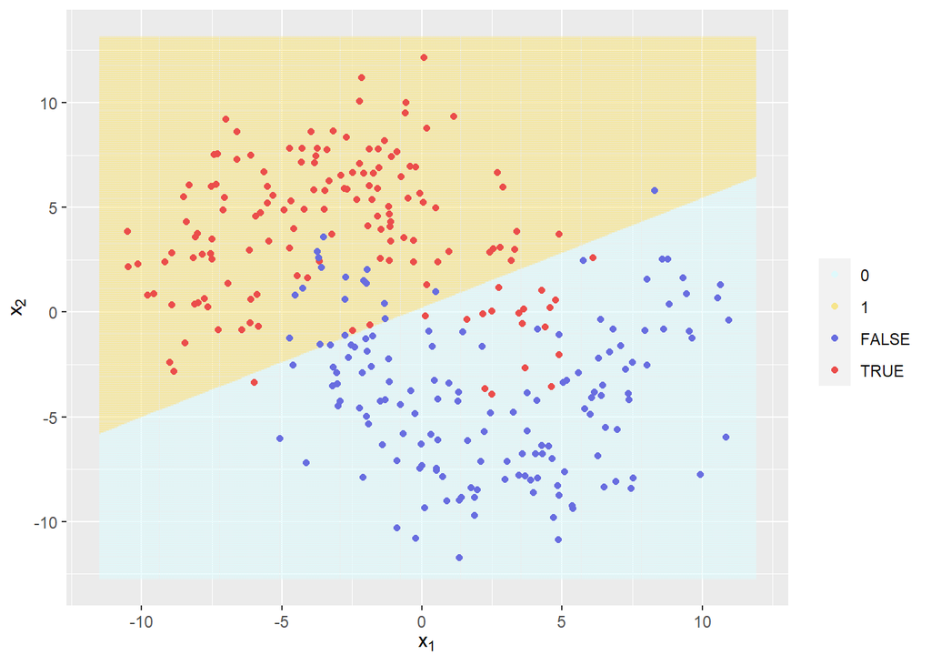

```r
# Make a grid of points around the input space
grid_1 <- expand.grid(x1 = seq(min(x[,1]) - 1,
                             max(x[,1]) + 1,
                             by = .05),
                    x2 = seq(min(x[,2]) - 1,
                             max(x[,2]) + 1,
                             by = .05))
# Feed the points through the trained neural network and get the classes (let the cut off be 0.5)
ff_grid_1 <- feedforward(x = data.matrix(grid_1[, c('x1', 'x2')]),
                       w1 = nnet1$w1,
                       w2 = nnet1$w2)
grid_1$class <- factor((ff_grid_1$output > .5) * 1,
                     labels = levels(dy))

# Plot the predicted classes on a grid behind the observed points.
p<-data.frame(x1=x[, 1],x2=x[, 2],class = y)

ggplot(p) + aes(x1, x2, colour = class) +
  geom_point(data = grid_1, size = .25, alpha = 1/3) +
  geom_point() +
  scale_color_manual(values = c("#dff9fb", "#f6e58d", "#686de0", "#eb4d4b"), name = "") +
  labs(x = expression(x[1]), y = expression(x[2]))
```

If you set the number of hidden layer as one, the result will be the same as regression and the boundary is liner.

## 7.6 Try Different Specification

Try training my neural network again with three nodes. Calculate the accuracy and plot the decision boundaries as before.

```r
nnet3 <- train.nn(x, y, hidden = 3, iterations = 1e3)
acc_3 <- mean((nnet3$output > .5) == y)
acc_3
```

```
## [1] 0.9433333
```

The accuracy of the neural network with three hidden node is 0.9433333

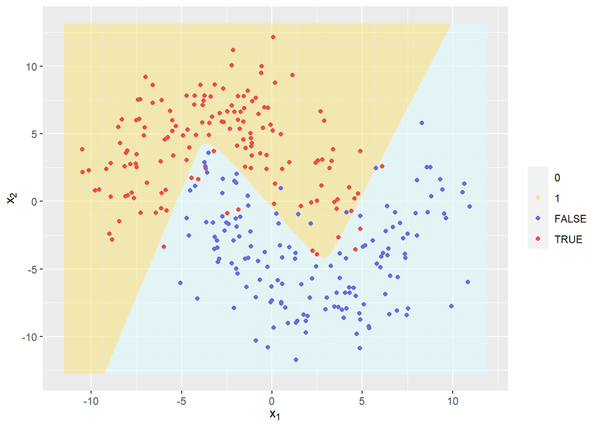

```r
grid_3 <- expand.grid(x1 = seq(min(x[,1]) - 1,
                             max(x[,1]) + 1,
                             by = .05),
                    x2 = seq(min(x[,2]) - 1,
                             max(x[,2]) + 1,
                             by = .05))
ff_grid_3 <- feedforward(x = data.matrix(grid_3[, c('x1', 'x2')]),
                       w1 = nnet3$w1,
                       w2 = nnet3$w2)
grid_3$class <- factor((ff_grid_3$output > .5) * 1,
                     labels = levels(dy))



ggplot(p) + aes(x1, x2, colour = class) +
  geom_point(data = grid_3, size = .25, alpha = 1/3) +
  geom_point() +
  scale_color_manual(values = c("#dff9fb", "#f6e58d", "#686de0", "#eb4d4b"), name = "") +
  labs(x = expression(x[1]), y = expression(x[2]))
```

How about 30 hidden nodes?

```r
nnet30 <- train.nn(x, y, hidden = 30, iterations = 1e3)
acc_30 <- mean((nnet30$output > .5) == y)
acc_30
```

```
## [1] 0.9533333
```

The accuracy of the neural network with 30 hidden node is 0.9533333

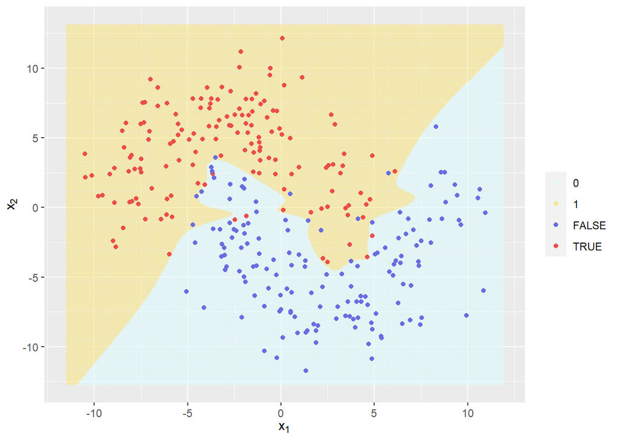

```r
grid_30 <- expand.grid(x1 = seq(min(x[,1]) - 1,
                             max(x[,1]) + 1,
                             by = .05),
                    x2 = seq(min(x[,2]) - 1,
                             max(x[,2]) + 1,
                             by = .05))
ff_grid_30 <- feedforward(x = data.matrix(grid_30[, c('x1', 'x2')]),
                       w1 = nnet30$w1,
                       w2 = nnet30$w2)
grid_30$class <- factor((ff_grid_30$output > .5) * 1,
                     labels = levels(dy))



ggplot(p) + aes(x1, x2, colour = class) +
  geom_point(data = grid_30, size = .25, alpha = 1/3) +
  geom_point() +
  scale_color_manual(values = c("#dff9fb", "#f6e58d", "#686de0", "#eb4d4b"), name = "") +
  labs(x = expression(x[1]), y = expression(x[2]))
```

The accuracy is improved. However, the boundary tries to capture noises and the model seems overfitted to the datasets.

# 8 Support Vector Machine

In this exercise, I see the performance of support vector machine referring UC Business Analytics R Programming Guide.

```r
library(tidyverse)
library(e1071) # SVM methodology
library(RSSL)  # generating sample datasets
```

## 8.1 Maximal Margin Classifier

Upon visual inspection, I can see that infinitely many lines exist that split the two classes. Below, I draw two example classification boundaries, and draw line segments from each observation to the boundary lines. The goal of the maximal margin classifier is to identify the linear boundary that maximizes the total distance between the line and the closest point in each class.

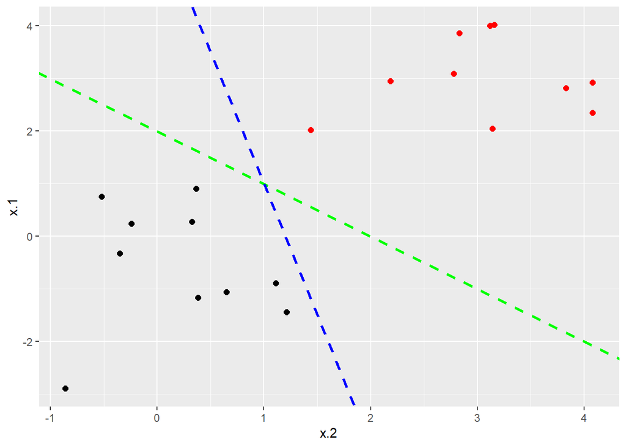

```r
set.seed(2022)

# Construct sample data set - completely separated
x <- matrix(rnorm(20*2), ncol = 2)
y <- c(rep(-1,10), rep(1,10))
x[y==1,] <- x[y==1,] + 3L
dat <- data.frame(x=x, y=as.factor(y))

# Plot data
ggplot(data = dat, aes(x = x.2, y = x.1, color = y)) +
  geom_point(size = 2) +
  scale_color_manual(values=c("#000000", "#FF0000")) +
  theme(legend.position = "none") +
  geom_abline(intercept = 2.0, slope = -1, color = "green",
                 linetype = "dashed", size = 1) + # example classification boundary 1
  geom_abline(intercept = 6.0, slope = -5, color = "blue", # example classification boundary 2
                 linetype = "dashed", size = 1)
```

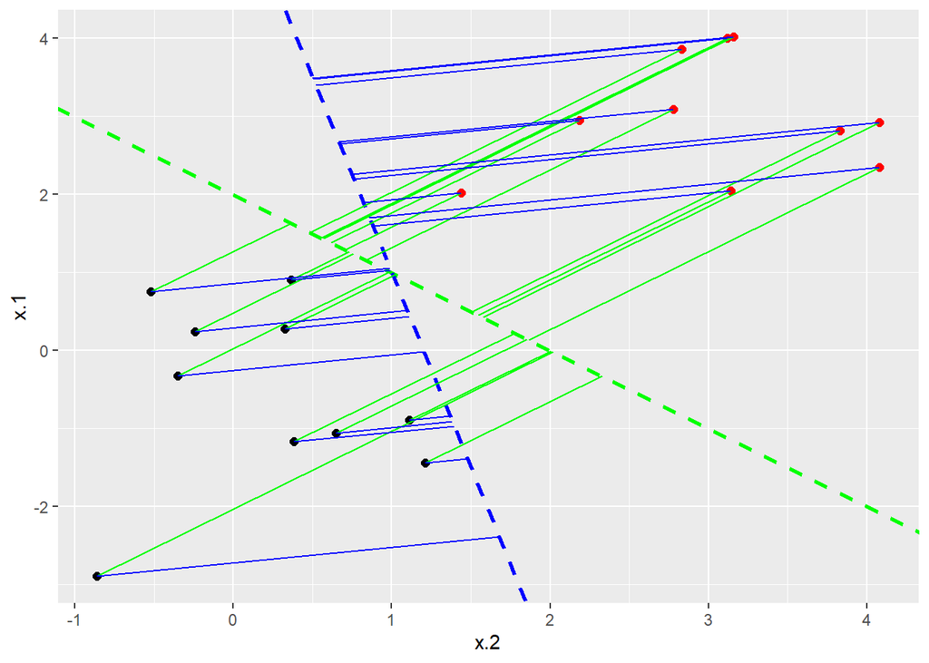

```r
# Draw perpenticular lines to the boundary lines
perp.segment.coord <- function(x0, y0, a=0, b=1){
 # finds endpoint for a perpendicular segment from the point (x0,y0) to the line (x1, y1)
  x1 <- (x0+b*y0-a*b)/(1+b^2)
  y1 <- a + b*x1
  list(x0=x0, y0=y0, x1=x1, y1=y1)
}

ss1 <- perp.segment.coord(dat$x.2, dat$x.1, 2.0, -1)
ss2 <- perp.segment.coord(dat$x.2, dat$x.1, 6.0, -5)

ggplot(data = dat, aes(x = x.2, y = x.1, color = y)) +
  geom_point(size = 2) +
  scale_color_manual(values=c("#000000", "#FF0000")) +
  theme(legend.position = "none") +
  geom_abline(intercept = 2.0, slope = -1, color = "green",
                 linetype = "dashed", size = 1) + # example classification boundary 1
  geom_abline(intercept = 6.0, slope = -5, color = "blue", # example classification boundary 2
                 linetype = "dashed", size = 1) +
  geom_segment(data=as.data.frame(ss1), aes(x = x0, y = y0, xend = x1, yend = y1), colour = "green") +
  geom_segment(data=as.data.frame(ss2), aes(x = x0, y = y0, xend = x1, yend = y1), colour = "blue")
```

Now, use the `svm()` function in the `e1071` package to find the linear boundary that maximizes the distance.

```r
# Fit Support Vector Machine model to data set
svmfit <- svm(y~., data = dat, kernel = "linear", scale = FALSE)
print(svmfit)
```

```
##
## Call:
## svm(formula = y ~ ., data = dat, kernel = "linear", scale = FALSE)
##
##
## Parameters:
##    SVM-Type:  C-classification
##  SVM-Kernel:  linear
##        cost:  1
##
## Number of Support Vectors:  2
```

Visualize the results using `plot()`. The points that fall on the margin and thus affect the classification line are called the **support vectors**.

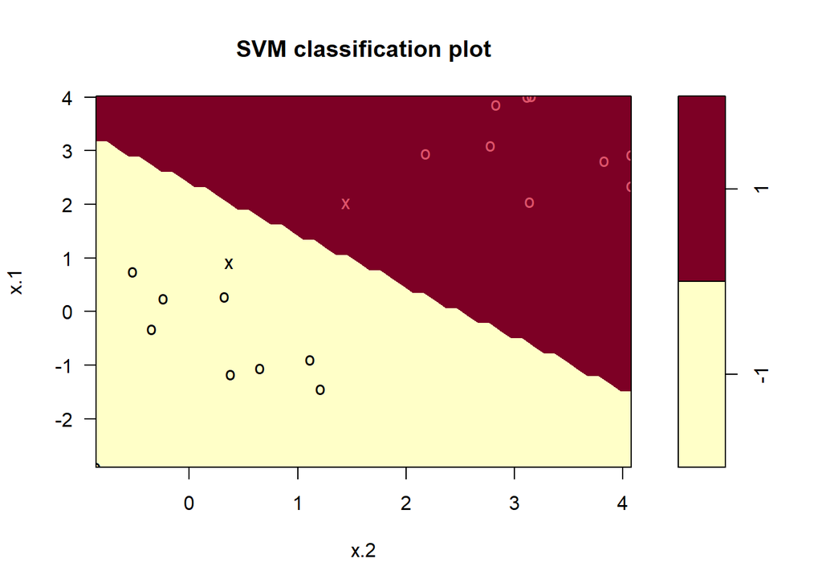

```r
# Plot Results
plot(svmfit, dat)
```

```r
svmfit$SV # support vectors
```

```
##         x.1       x.2
## 1  0.900142 0.3644608
## 13 2.018173 1.4410811
```

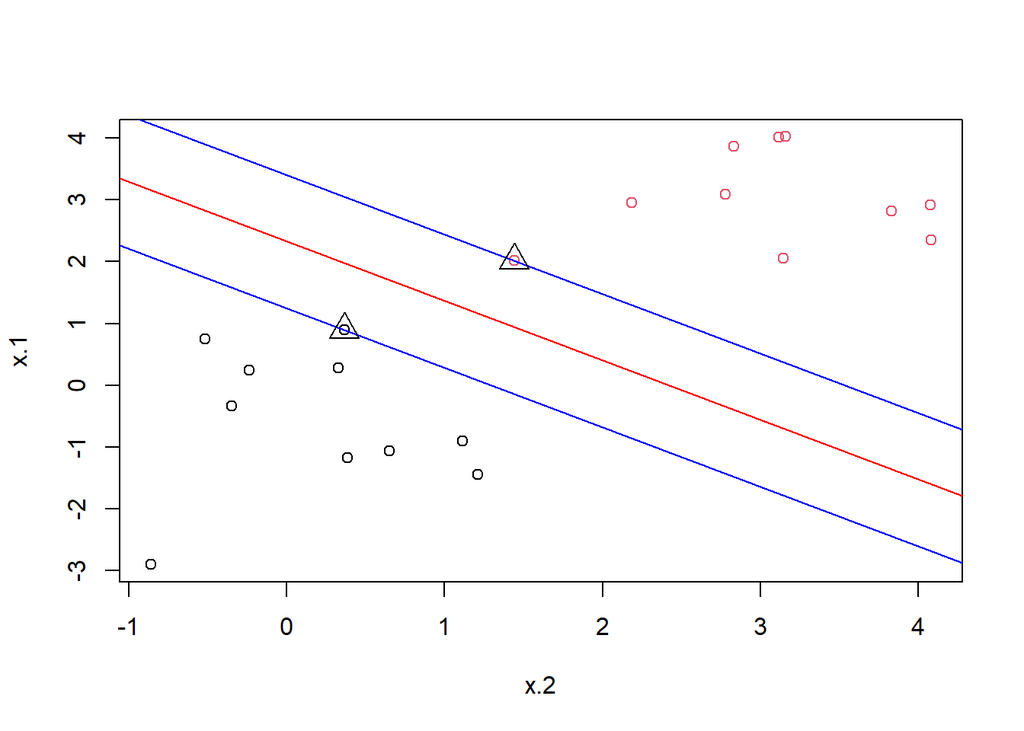

```r
# manually plot data and separating hyperplane
plot(x.1 ~ x.2, data = dat, col=dat$y)
cf <- coef(svmfit)
abline(-cf[1]/cf[2], -cf[3]/cf[2], col = "red")
# plot margin and mark support vectors
abline(-(cf[1] + 1)/cf[2], -cf[3]/cf[2], col = "blue")
abline(-(cf[1] - 1)/cf[2], -cf[3]/cf[2], col = "blue")
points(svmfit$SV[,2], svmfit$SV[,1], pch = 2, cex = 2)
```

In the plot, points that are represented by an “X” are the support vectors, or the points that directly affect the classification line. The points marked with an “o” are the other points, which don’t affect the calculation of the line. This principle will lay the foundation for support vector machines.

## 8.2 Support Vector Classifiers

Most real data sets will not be fully separable by a linear boundary. To handle such data, I must use modified methodology. I simulate a new data set where the classes are more mixed.

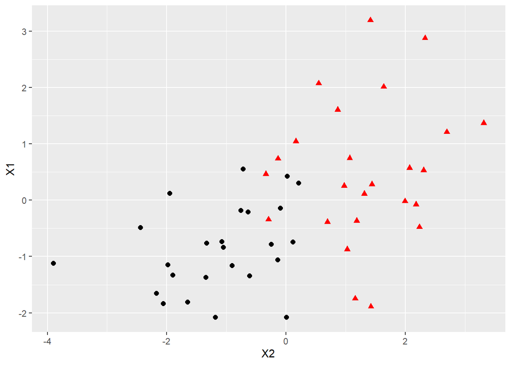

```r
set.seed(2022)
d <- generate2ClassGaussian(50, 2)
d$Class <- as.factor(d$Class)

# Plot data set
ggplot(data = d, aes(x = X2, y = X1, color = Class, shape = Class)) +
  geom_point(size = 2) +
  scale_color_manual(values=c("#000000", "#FF0000")) +
  theme(legend.position = "none")
```

Whether the data is separable or not, the `svm` command syntax is the same. In the case of data that is not linearly separable, however, the `cost` argument takes on real importance. This quantifies the penalty associated with having an observation on the wrong side of the classification boundary. Moreover, the `kernel` argument allows us to select a function based on the assumed shape of the data. For now I assume the data are linearly separable.

Use a `linear` kernel to fit an SVM to the model data set, with a cost of 10.

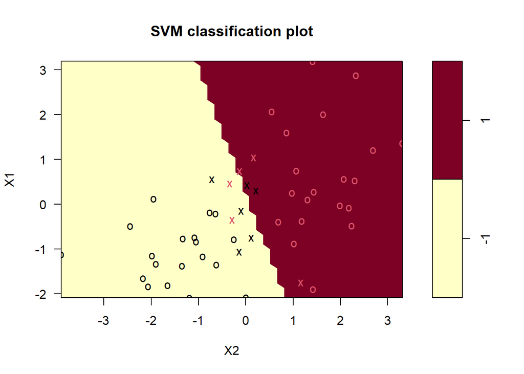

```r
# Fit Support Vector Machine model to data set
svmfit2 <- svm(Class ~ ., data = d, kernel = "linear", cost = 10)
# Plot Results
plot(svmfit2, d)
```

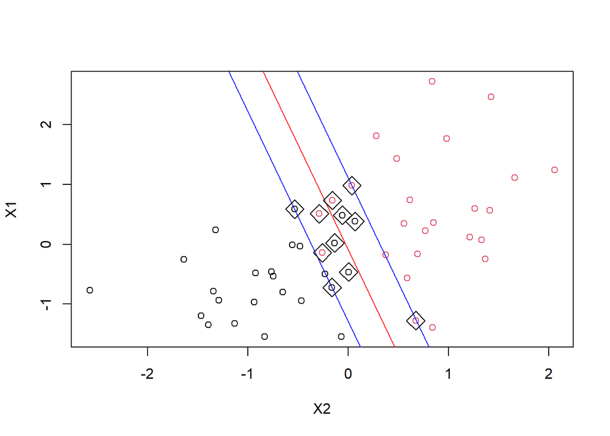

```r
# manually plot data and separating hyperplane
scaled.d <- scale(d[,1:2]) # Note that we've scaled the predictors for svmfit2
plot(X1 ~ X2, data = scaled.d, col=d$Class)
cf <- coef(svmfit2)
abline(-cf[1]/cf[2], -cf[3]/cf[2], col = "red")

# plot margin and mark support vectors
abline(-(cf[1] + 1)/cf[2], -cf[3]/cf[2], col = "blue")
abline(-(cf[1] - 1)/cf[2], -cf[3]/cf[2], col = "blue")
points(svmfit2$SV[,2], svmfit2$SV[,1], pch = 5, cex = 2)
```

Then, instead of specifying a cost up front, use the `tune` function from `e1071` to test various costs and identify which value produces the best fitting model. Use the `ranges` argument, which takes a list of vectors, to define the range of costs we are interested in. Utilize a cost of `list(c(0.001, 0.01, 0.1, 1, 5, 10, 100))`.

```r
set.seed(2022)
# Find optimal cost of misclassification
tune.out <- tune(svm, Class ~ ., data = d, kernel = "linear",
                 ranges = list(cost = c(0.001, 0.01, 0.1, 1, 5, 10, 100)))

# Extract the best model
bestmod <- tune.out$best.model
print(bestmod)
```

```
##
## Call:
## best.tune(method = svm, train.x = Class ~ ., data = d, ranges = list(cost = c(0.001,
##     0.01, 0.1, 1, 5, 10, 100)), kernel = "linear")
##
##
## Parameters:
##    SVM-Type:  C-classification
##  SVM-Kernel:  linear
##        cost:  1
##
## Number of Support Vectors:  16
```

For the data set, the optimal cost is calculated to be 1. Once this model has been identified, I can construct a table of predicted classes against true classes as follows:

```r
misclass <- table(predict = bestmod$fitted, truth = d$Class)
misclass
```

```
##        truth
## predict -1  1
##      -1 24  3
##      1   1 22
```

## 8.3 Support Vector Machines (Nonlinear)

Support Vector Classifiers are a subset of the group of classification structures known as Support Vector Machines. Support Vector Machines can construct classification boundaries that are nonlinear in shape. The options for classification structures using the `svm` command from the `e1071` package are linear, polynomial, radial, and sigmoid. To demonstrate a nonlinear classification boundary, I will construct a new data set.

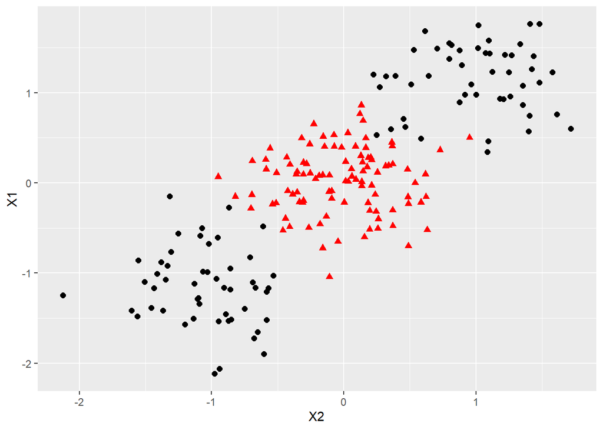

```r
# Construct larger random data set
set.seed(2022)
d <- generateABA(200, 2, var = 0.15)
d$Class <- as.factor(d$Class)

# Plot data
ggplot(data = d, aes(x = X2, y = X1, color = Class, shape = Class)) +
  geom_point(size = 2) +
  scale_color_manual(values=c("#000000", "#FF0000")) +
  theme(legend.position = "none")
```

Notice that the data is not linearly separable, and furthermore, isn’t all clustered together in a single group. There are two sections of class 1 observations with a cluster of class 2 observations in between.

To demonstrate the power of SVMs, take 100 random observations from the set and use this *train* data to construct the boundary. Set `kernel = "radial"` based on the shape of our data and plot the results.

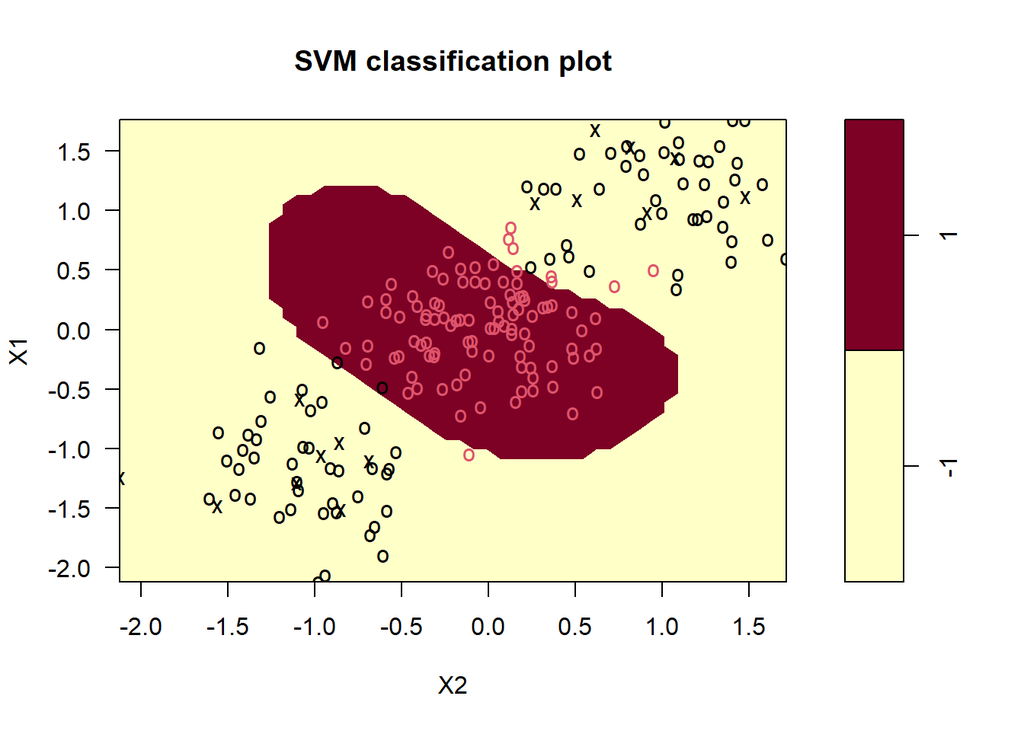

```r
# Set pseudorandom number generator
set.seed(2022)

# Sample training data and fit model
train <- base::sample(200, 100, replace = FALSE)
train <- train[order(train)]

svmfit3 <- svm(Class ~ ., data = d[train,], kernel = "radial", gamma = 1, cost = 10)

# Plot classifier
plot(svmfit3, d)
```

I see that, at least visually, the SVM does a reasonable job of separating the two classes. To fit the model, I used `cost = 10`, but as mentioned previously, it isn’t usually obvious which cost will produce the optimal classification boundary. Then, I can use the `tune` command to try several different values of cost as well as several different values of gamma, a scaling parameter used to fit nonlinear boundaries.

Again, use the `tune` function from `e1071` and the train data to test various costs and gamma, a scaling parameter used to fit nonlinear boundaries.

```r
set.seed(2022)
# Tune model to find optimal cost, gamma values
tune.out <- tune(svm, Class ~ ., data = d[train,], kernel = "radial",
                 ranges = list(cost = c(0.1,1,10,20,50,100), # A list of parameter vectors for cost
                 gamma = c(0.5,1,2,3,4)))

# Show best model
tune.out$best.model
```

```
##
## Call:
## best.tune(method = svm, train.x = Class ~ ., data = d[train, ], ranges = list(cost = c(0.1,
##     1, 10, 20, 50, 100), gamma = c(0.5, 1, 2, 3, 4)), kernel = "radial")
##
##
## Parameters:
##    SVM-Type:  C-classification
##  SVM-Kernel:  radial
##        cost:  10
##
## Number of Support Vectors:  11
```

Now, I will validate this best model using the remaining *test* data. Predict the label of the test data using the best model and create a contingency table to check the results.

```r
# validate model performance
test.pred <- predict(tune.out$best.model, newx = d[-train,])
valid <- table(true = d[-train, "Class"], pred = test.pred)
valid
```

```
##     pred
## true -1  1
##   -1 47  1
##   1   4 48
```

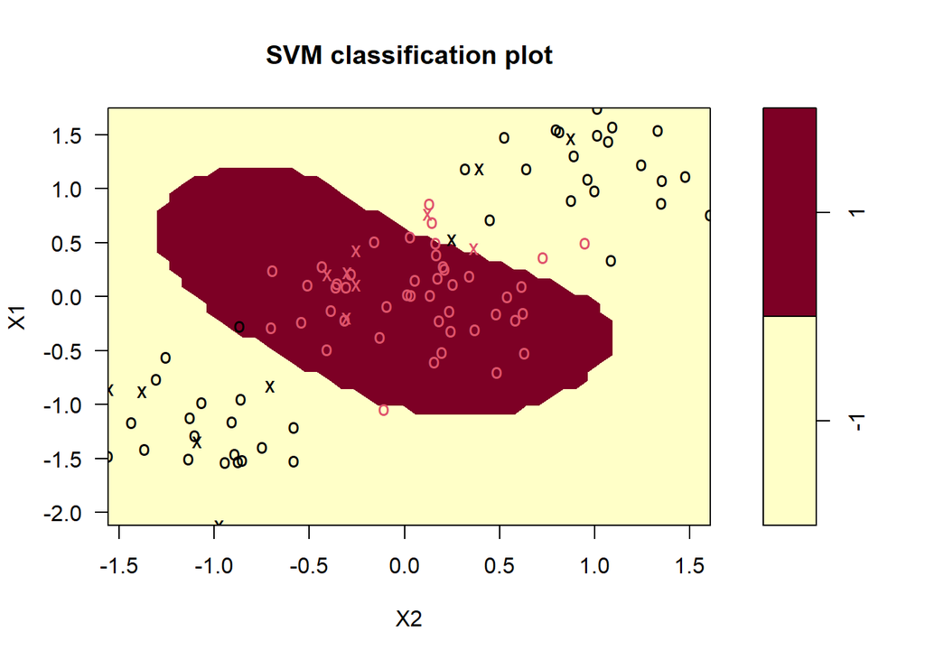

```r
d_test <- d[-train, ]
plot(svmfit3, d_test)
```

## 8.4 SVMs for Multiple Classes

The procedure does not change for datasets that involve more than two classes of observations. I construct a dataset that contains three classes instead of two:

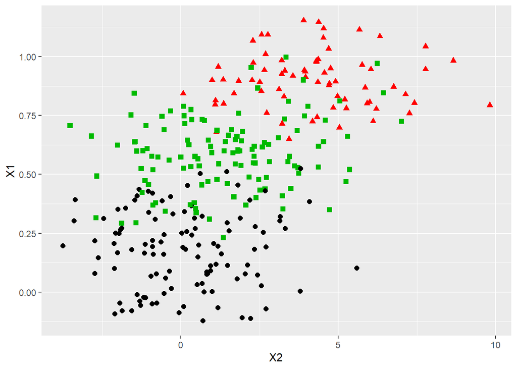

```r
set.seed(2022)
x <- runif(300)
y <- 5 * x ^ 2 + rnorm(length(x), sd = 2)
Class <- as.factor(ifelse(x < 0.4, "A",
                 ifelse(x > 0.8, "B",
                        "C")))
x <- x + runif(length(x), -0.2, 0.2) # Some noise after defining the groups
d <- data.frame(X1 = x, X2 = y, Class = Class)


ggplot(data = d, aes(x = X2, y = X1, color = Class, shape = Class)) +
  geom_point(size = 2) +
  scale_color_manual(values=c("#000000", "#FF0000", "#00BA00")) +
  theme(legend.position = "none")
```

Fit a support vector machine with following specification: `kernel = "radial", cost = 10, gamma = 1`. See how well the model fits the data by using the `predict` command and creating a contingency table.

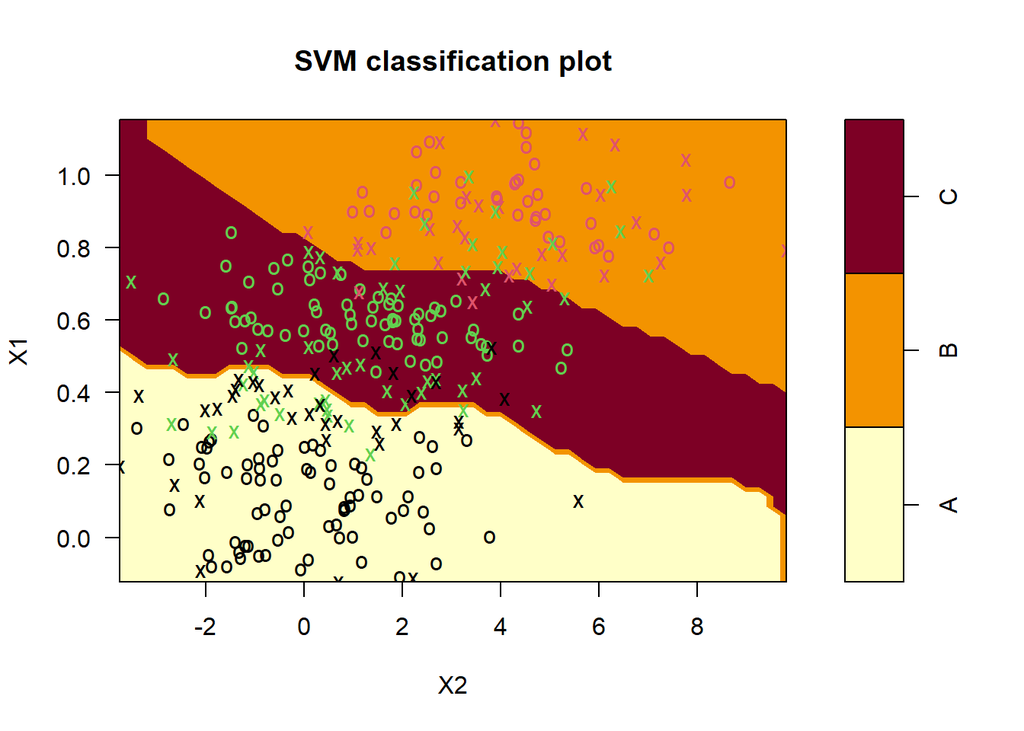

```r
# Fit model
svmfit <- svm(Class ~., data = d, kernel = "radial", cost = 10, gamma = 1)

# Plot results
plot(svmfit, d)
```

```r
# Construct table
table(predict = svmfit$fitted, truth = d$Class)
```

```
##        truth
## predict   A   B   C
##       A 102   0  13
##       B   0  65  12
##       C   8   4  96
```

The results and interpretation are similar to two-class classification.